# Project: Identify Customer Segments

In this project, you will apply unsupervised learning techniques to identify segments of the population that form the core customer base for a mail-order sales company in Germany. These segments can then be used to direct marketing campaigns towards audiences that will have the highest expected rate of returns. The data that you will use has been provided by our partners at Bertelsmann Arvato Analytics, and represents a real-life data science task.

This notebook will help you complete this task by providing a framework within which you will perform your analysis steps. In each step of the project, you will see some text describing the subtask that you will perform, followed by one or more code cells for you to complete your work. **Feel free to add additional code and markdown cells as you go along so that you can explore everything in precise chunks.** The code cells provided in the base template will outline only the major tasks, and will usually not be enough to cover all of the minor tasks that comprise it.

It should be noted that while there will be precise guidelines on how you should handle certain tasks in the project, there will also be places where an exact specification is not provided. **There will be times in the project where you will need to make and justify your own decisions on how to treat the data.** These are places where there may not be only one way to handle the data. In real-life tasks, there may be many valid ways to approach an analysis task. One of the most important things you can do is clearly document your approach so that other scientists can understand the decisions you've made.

At the end of most sections, there will be a Markdown cell labeled **Discussion**. In these cells, you will report your findings for the completed section, as well as document the decisions that you made in your approach to each subtask. **Your project will be evaluated not just on the code used to complete the tasks outlined, but also your communication about your observations and conclusions at each stage.**

```python
# import libraries here; add more as necessary
import numpy as np
import pandas as pd
import matplotlib.pyplot as plt
import seaborn as sns

# magic word for producing visualizations in notebook
%matplotlib inline


'''
Import note: The classroom currently uses sklearn version 0.19.
If you need to use an imputer, it is available in sklearn.preprocessing.Imputer,
instead of sklearn.impute as in newer versions of sklearn.
'''
```

```
'\nImport note: The classroom currently uses sklearn version 0.19.\nIf you need to use an imputer, it is available in sklearn.preprocessing.Imputer,\ninstead of sklearn.impute as in newer versions of sklearn.\n'
```

### Step 0: Load the Data

There are four files associated with this project (not including this one):

Each row of the demographics files represents a single person, but also includes information outside of individuals, including information about their household, building, and neighborhood. You will use this information to cluster the general population into groups with similar demographic properties. Then, you will see how the people in the customers dataset fit into those created clusters. The hope here is that certain clusters are over-represented in the customers data, as compared to the general population; those over-represented clusters will be assumed to be part of the core userbase. This information can then be used for further applications, such as targeting for a marketing campaign.

To start off with, load in the demographics data for the general population into a pandas DataFrame, and do the same for the feature attributes summary. Note for all of the `.csv` data files in this project: they're semicolon (`;`) delimited, so you'll need an additional argument in your [`read_csv()`](https://pandas.pydata.org/pandas-docs/stable/generated/pandas.read_csv.html) call to read in the data properly. Also, considering the size of the main dataset, it may take some time for it to load completely.

Once the dataset is loaded, it's recommended that you take a little bit of time just browsing the general structure of the dataset and feature summary file. You'll be getting deep into the innards of the cleaning in the first major step of the project, so gaining some general familiarity can help you get your bearings.

```python
# Load in the general demographics data.
azdias = pd.read_csv('./Udacity_AZDIAS_Subset.csv', sep=';')

# Load in the feature summary file.
feat_info = pd.read_csv('./AZDIAS_Feature_Summary.csv', sep=';')
```

```python
azdias.head()
feat_info
```

|  | attribute | information_level | type | missing_or_unknown |
| --- | --- | --- | --- | --- |
| 0 | AGER_TYP | person | categorical | [-1,0] |
| 1 | ALTERSKATEGORIE_GROB | person | ordinal | [-1,0,9] |
| 2 | ANREDE_KZ | person | categorical | [-1,0] |
| 3 | CJT_GESAMTTYP | person | categorical | [0] |
| 4 | FINANZ_MINIMALIST | person | ordinal | [-1] |
| 5 | FINANZ_SPARER | person | ordinal | [-1] |
| 6 | FINANZ_VORSORGER | person | ordinal | [-1] |
| 7 | FINANZ_ANLEGER | person | ordinal | [-1] |
| 8 | FINANZ_UNAUFFAELLIGER | person | ordinal | [-1] |
| 9 | FINANZ_HAUSBAUER | person | ordinal | [-1] |
| 10 | FINANZTYP | person | categorical | [-1] |
| 11 | GEBURTSJAHR | person | numeric | [0] |
| 12 | GFK_URLAUBERTYP | person | categorical | [] |
| 13 | GREEN_AVANTGARDE | person | categorical | [] |
| 14 | HEALTH_TYP | person | ordinal | [-1,0] |
| 15 | LP_LEBENSPHASE_FEIN | person | mixed | [0] |
| 16 | LP_LEBENSPHASE_GROB | person | mixed | [0] |
| 17 | LP_FAMILIE_FEIN | person | categorical | [0] |
| 18 | LP_FAMILIE_GROB | person | categorical | [0] |
| 19 | LP_STATUS_FEIN | person | categorical | [0] |
| 20 | LP_STATUS_GROB | person | categorical | [0] |
| 21 | NATIONALITAET_KZ | person | categorical | [-1,0] |
| 22 | PRAEGENDE_JUGENDJAHRE | person | mixed | [-1,0] |
| 23 | RETOURTYP_BK_S | person | ordinal | [0] |
| 24 | SEMIO_SOZ | person | ordinal | [-1,9] |
| 25 | SEMIO_FAM | person | ordinal | [-1,9] |
| 26 | SEMIO_REL | person | ordinal | [-1,9] |
| 27 | SEMIO_MAT | person | ordinal | [-1,9] |
| 28 | SEMIO_VERT | person | ordinal | [-1,9] |
| 29 | SEMIO_LUST | person | ordinal | [-1,9] |
| ... | ... | ... | ... | ... |
| 55 | OST_WEST_KZ | building | categorical | [-1] |
| 56 | WOHNLAGE | building | mixed | [-1] |
| 57 | CAMEO_DEUG_2015 | microcell_rr4 | categorical | [-1,X] |
| 58 | CAMEO_DEU_2015 | microcell_rr4 | categorical | [XX] |
| 59 | CAMEO_INTL_2015 | microcell_rr4 | mixed | [-1,XX] |
| 60 | KBA05_ANTG1 | microcell_rr3 | ordinal | [-1] |
| 61 | KBA05_ANTG2 | microcell_rr3 | ordinal | [-1] |
| 62 | KBA05_ANTG3 | microcell_rr3 | ordinal | [-1] |
| 63 | KBA05_ANTG4 | microcell_rr3 | ordinal | [-1] |
| 64 | KBA05_BAUMAX | microcell_rr3 | mixed | [-1,0] |
| 65 | KBA05_GBZ | microcell_rr3 | ordinal | [-1,0] |
| 66 | BALLRAUM | postcode | ordinal | [-1] |
| 67 | EWDICHTE | postcode | ordinal | [-1] |
| 68 | INNENSTADT | postcode | ordinal | [-1] |
| 69 | GEBAEUDETYP_RASTER | region_rr1 | ordinal | [] |
| 70 | KKK | region_rr1 | ordinal | [-1,0] |
| 71 | MOBI_REGIO | region_rr1 | ordinal | [] |
| 72 | ONLINE_AFFINITAET | region_rr1 | ordinal | [] |
| 73 | REGIOTYP | region_rr1 | ordinal | [-1,0] |
| 74 | KBA13_ANZAHL_PKW | macrocell_plz8 | numeric | [] |
| 75 | PLZ8_ANTG1 | macrocell_plz8 | ordinal | [-1] |
| 76 | PLZ8_ANTG2 | macrocell_plz8 | ordinal | [-1] |
| 77 | PLZ8_ANTG3 | macrocell_plz8 | ordinal | [-1] |
| 78 | PLZ8_ANTG4 | macrocell_plz8 | ordinal | [-1] |
| 79 | PLZ8_BAUMAX | macrocell_plz8 | mixed | [-1,0] |
| 80 | PLZ8_HHZ | macrocell_plz8 | ordinal | [-1] |
| 81 | PLZ8_GBZ | macrocell_plz8 | ordinal | [-1] |
| 82 | ARBEIT | community | ordinal | [-1,9] |
| 83 | ORTSGR_KLS9 | community | ordinal | [-1,0] |
| 84 | RELAT_AB | community | ordinal | [-1,9] |

85 rows × 4 columns

```python
# Check the structure of the data after it's loaded (e.g. print the number of
# rows and columns, print the first few rows).

print(azdias.shape)
feat_info.shape
```

```
(891221, 85)
```

```
(85, 4)
```

> **Tip**: Add additional cells to keep everything in reasonably-sized chunks! Keyboard shortcut `esc --> a` (press escape to enter command mode, then press the 'A' key) adds a new cell before the active cell, and `esc --> b` adds a new cell after the active cell. If you need to convert an active cell to a markdown cell, use `esc --> m` and to convert to a code cell, use `esc --> y`.

## Step 1: Preprocessing

### Step 1.1: Assess Missing Data

The feature summary file contains a summary of properties for each demographics data column. You will use this file to help you make cleaning decisions during this stage of the project. First of all, you should assess the demographics data in terms of missing data. Pay attention to the following points as you perform your analysis, and take notes on what you observe. Make sure that you fill in the **Discussion** cell with your findings and decisions at the end of each step that has one!

#### Step 1.1.1: Convert Missing Value Codes to NaNs

The fourth column of the feature attributes summary (loaded in above as `feat_info`) documents the codes from the data dictionary that indicate missing or unknown data. While the file encodes this as a list (e.g. `[-1,0]`), this will get read in as a string object. You'll need to do a little bit of parsing to make use of it to identify and clean the data. Convert data that matches a 'missing' or 'unknown' value code into a numpy NaN value. You might want to see how much data takes on a 'missing' or 'unknown' code, and how much data is naturally missing, as a point of interest.

**As one more reminder, you are encouraged to add additional cells to break up your analysis into manageable chunks.**

```python
#missing_or_unknown list max length
feat_info.iloc[:, 3].apply(lambda x: x.strip("[").strip("]").split(",").__len__()).max()
```

```
3
```

```python
feat_info['attribute'][1]
azdias[feat_info['attribute'][1]]
feat_info['missing_or_unknown'][1].__str__().strip("[").strip("]").split(",")
feat_info.shape
feat_info['attribute'][3]
```

```
'CJT_GESAMTTYP'
```

```python
feat_info.iloc[:, [0, 3]]
```

|  | attribute | missing_or_unknown |
| --- | --- | --- |
| 0 | AGER_TYP | [-1,0] |
| 1 | ALTERSKATEGORIE_GROB | [-1,0,9] |
| 2 | ANREDE_KZ | [-1,0] |
| 3 | CJT_GESAMTTYP | [0] |
| 4 | FINANZ_MINIMALIST | [-1] |
| 5 | FINANZ_SPARER | [-1] |
| 6 | FINANZ_VORSORGER | [-1] |
| 7 | FINANZ_ANLEGER | [-1] |
| 8 | FINANZ_UNAUFFAELLIGER | [-1] |
| 9 | FINANZ_HAUSBAUER | [-1] |
| 10 | FINANZTYP | [-1] |
| 11 | GEBURTSJAHR | [0] |
| 12 | GFK_URLAUBERTYP | [] |
| 13 | GREEN_AVANTGARDE | [] |
| 14 | HEALTH_TYP | [-1,0] |
| 15 | LP_LEBENSPHASE_FEIN | [0] |
| 16 | LP_LEBENSPHASE_GROB | [0] |
| 17 | LP_FAMILIE_FEIN | [0] |
| 18 | LP_FAMILIE_GROB | [0] |
| 19 | LP_STATUS_FEIN | [0] |
| 20 | LP_STATUS_GROB | [0] |
| 21 | NATIONALITAET_KZ | [-1,0] |
| 22 | PRAEGENDE_JUGENDJAHRE | [-1,0] |
| 23 | RETOURTYP_BK_S | [0] |
| 24 | SEMIO_SOZ | [-1,9] |
| 25 | SEMIO_FAM | [-1,9] |
| 26 | SEMIO_REL | [-1,9] |
| 27 | SEMIO_MAT | [-1,9] |
| 28 | SEMIO_VERT | [-1,9] |
| 29 | SEMIO_LUST | [-1,9] |
| ... | ... | ... |
| 55 | OST_WEST_KZ | [-1] |
| 56 | WOHNLAGE | [-1] |
| 57 | CAMEO_DEUG_2015 | [-1,X] |
| 58 | CAMEO_DEU_2015 | [XX] |
| 59 | CAMEO_INTL_2015 | [-1,XX] |
| 60 | KBA05_ANTG1 | [-1] |
| 61 | KBA05_ANTG2 | [-1] |
| 62 | KBA05_ANTG3 | [-1] |
| 63 | KBA05_ANTG4 | [-1] |
| 64 | KBA05_BAUMAX | [-1,0] |
| 65 | KBA05_GBZ | [-1,0] |
| 66 | BALLRAUM | [-1] |
| 67 | EWDICHTE | [-1] |
| 68 | INNENSTADT | [-1] |
| 69 | GEBAEUDETYP_RASTER | [] |
| 70 | KKK | [-1,0] |
| 71 | MOBI_REGIO | [] |
| 72 | ONLINE_AFFINITAET | [] |
| 73 | REGIOTYP | [-1,0] |
| 74 | KBA13_ANZAHL_PKW | [] |
| 75 | PLZ8_ANTG1 | [-1] |
| 76 | PLZ8_ANTG2 | [-1] |
| 77 | PLZ8_ANTG3 | [-1] |
| 78 | PLZ8_ANTG4 | [-1] |
| 79 | PLZ8_BAUMAX | [-1,0] |
| 80 | PLZ8_HHZ | [-1] |
| 81 | PLZ8_GBZ | [-1] |
| 82 | ARBEIT | [-1,9] |
| 83 | ORTSGR_KLS9 | [-1,0] |
| 84 | RELAT_AB | [-1,9] |

85 rows × 2 columns

```python
feat_info['missing_or_unknown'][4].strip("[]").split(",")
```

```
['-1']
```

```python
# Identify missing or unknown data values and convert them to NaNs.


checklist = []

for i in range(0, feat_info.shape[0]):
    chg =feat_info['missing_or_unknown'][i].strip("[]").split(",")
    print(chg)
    for item in chg:

        if item.isdigit():
            if azdias[feat_info['attribute'][i]].dtype == float:
                    item = float(item)
            if azdias[feat_info['attribute'][i]].dtype == int:
                    item = int(item)
        print(item)
        print(feat_info['attribute'][i])

        azdias[feat_info['attribute'][i]] = azdias[feat_info['attribute'][i]].apply(lambda x: np.nan if x.__str__() == item.__str__() else x)
```

```
['-1', '0']
-1
AGER_TYP
0.0
AGER_TYP
['-1', '0', '9']
-1
ALTERSKATEGORIE_GROB
0
ALTERSKATEGORIE_GROB
9
ALTERSKATEGORIE_GROB
['-1', '0']
-1
ANREDE_KZ
0
ANREDE_KZ
['0']
0.0
CJT_GESAMTTYP
['-1']
-1
FINANZ_MINIMALIST
['-1']
-1
FINANZ_SPARER
['-1']
-1
FINANZ_VORSORGER
['-1']
-1
FINANZ_ANLEGER
['-1']
-1
FINANZ_UNAUFFAELLIGER
['-1']
-1
FINANZ_HAUSBAUER
['-1']
-1
```

[output cut: 274 more lines]

```
['-1', '9']
-1
ARBEIT
9.0
ARBEIT
['-1', '0']
-1
ORTSGR_KLS9
0.0
ORTSGR_KLS9
['-1', '9']
-1
RELAT_AB
9.0
RELAT_AB
```

```python
# Identify missing or unknown data values and convert them to NaNs.

def to_nan(data):
    checklist = []

    for i in range(0, feat_info.shape[0]):
        chg =feat_info['missing_or_unknown'][i].strip("[]").split(",")
        print(chg)
        for item in chg:

            if item.isdigit():
                if data[feat_info['attribute'][i]].dtype == float:
                        item = float(item)
                if data[feat_info['attribute'][i]].dtype == int:
                        item = int(item)
            print(item)
            print(feat_info['attribute'][i])

            data[feat_info['attribute'][i]] = data[feat_info['attribute'][i]].apply(lambda x: np.nan if x.__str__() == item.__str__() else x)

    return data
```

```python
feat_info.shape
```

```
(85, 4)
```

```python
print(azdias["ALTERSKATEGORIE_GROB"].describe())  # no -1, 0 , or 9
print(azdias["RELAT_AB"].describe()) #no 9
print(azdias["ARBEIT"].describe()) # no -1
print(azdias["SEMIO_SOZ"].describe()) # no -1 nor 9
```

```
count    888340.000000
mean          2.757217
std           1.009951
min           1.000000
25%           2.000000
50%           3.000000
75%           4.000000
max           4.000000
Name: ALTERSKATEGORIE_GROB, dtype: float64
count    793846.000000
mean          3.071033
std           1.360532
min           1.000000
25%           2.000000
50%           3.000000
75%           4.000000
max           5.000000
Name: RELAT_AB, dtype: float64
count    793846.000000
mean          3.166686
std           0.999072
min           1.000000
25%           3.000000
50%           3.000000
75%           4.000000
max           5.000000
Name: ARBEIT, dtype: float64
count    891221.000000
mean          3.945860
std           1.946564
min           1.000000
25%           2.000000
50%           4.000000
75%           6.000000
max           7.000000
Name: SEMIO_SOZ, dtype: float64
```

#### Step 1.1.2: Assess Missing Data in Each Column

How much missing data is present in each column? There are a few columns that are outliers in terms of the proportion of values that are missing. You will want to use matplotlib's [`hist()`](https://matplotlib.org/api/_as_gen/matplotlib.pyplot.hist.html) function to visualize the distribution of missing value counts to find these columns. Identify and document these columns. While some of these columns might have justifications for keeping or re-encoding the data, for this project you should just remove them from the dataframe. (Feel free to make remarks about these outlier columns in the discussion, however!)

For the remaining features, are there any patterns in which columns have, or share, missing data?

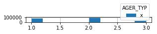

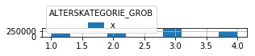

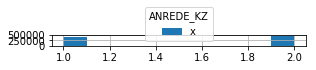

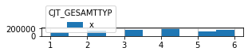

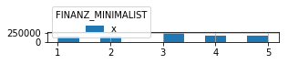

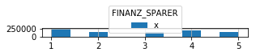

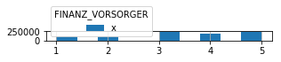

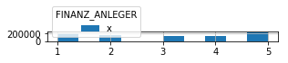

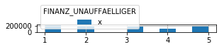

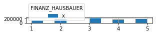

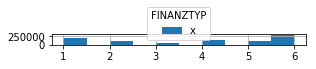

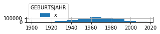

[73 more figures not shown]

```python
# Perform an assessment of how much missing data there is in each column of the
# dataset.

for i in range(0, azdias.shape[1]):
    plt.figure(figsize=(10, 10))
    plt.subplot(43, 2, i+1)
    azdias[azdias.columns[i]].hist()
    plt.legend(['x','y'], title = azdias.columns[i])
```

```python
df_outliers = pd.DataFrame(azdias.isna().sum()>200000)
df_outliers[df_outliers[0]==True].index
#Adding these columns to dellist below
```

```
Index(['AGER_TYP', 'GEBURTSJAHR', 'TITEL_KZ', 'ALTER_HH', 'KK_KUNDENTYP',
       'KBA05_BAUMAX'],
      dtype='object')
```

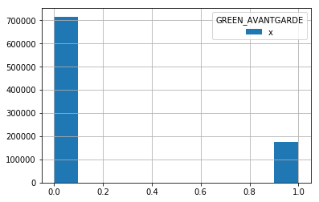

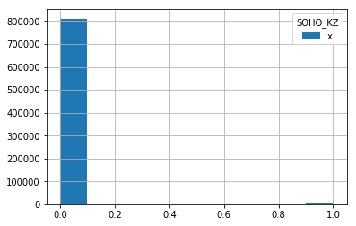

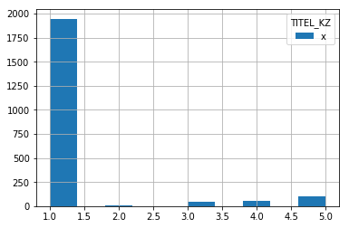

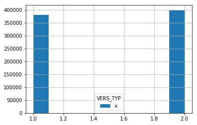

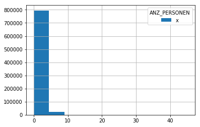

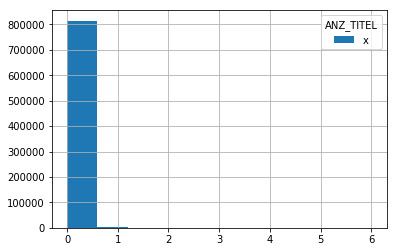

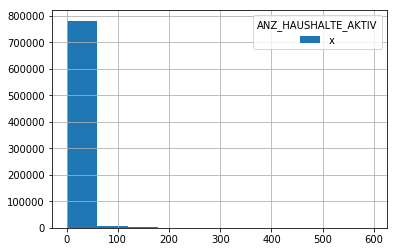

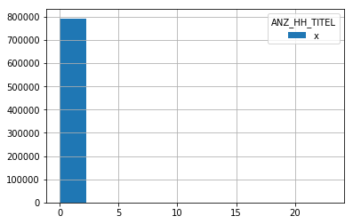

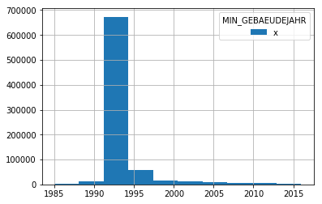

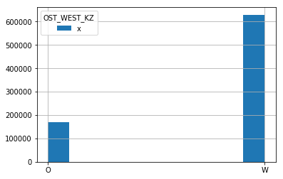

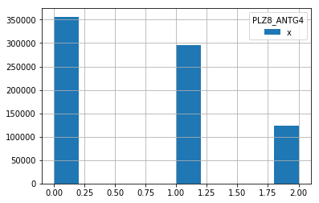

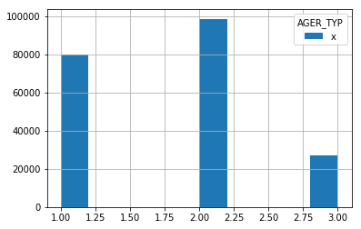

[4 more figures not shown]

```python
# Investigate patterns in the amount of missing data in each column.
dellist = ["GREEN_AVANTGARDE", "SOHO_KZ", "TITEL_KZ", "VERS_TYP", "ANZ_PERSONEN","ANZ_TITEL", "ANZ_HAUSHALTE_AKTIV", "ANZ_HH_TITEL", "MIN_GEBAEUDEJAHR", "OST_WEST_KZ", "PLZ8_ANTG4", "AGER_TYP", "GEBURTSJAHR", "ALTER_HH", "KK_KUNDENTYP",
       "KBA05_BAUMAX"]

for delitem in dellist:
    azdias[delitem].hist()
    plt.legend(['x','y'], title = delitem)
    plt.show()
```

```python
for delitem in dellist:
    print(azdias[delitem].describe())
    print("na item count --------- {} ".format(azdias[delitem].isna().sum()))
    print("na count ratio -------- {} ".format(azdias[delitem].isna().sum()/azdias.shape[0]))
```

```
count    891221.000000
mean          0.196612
std           0.397437
min           0.000000
25%           0.000000
50%           0.000000
75%           0.000000
max           1.000000
Name: GREEN_AVANTGARDE, dtype: float64
na item count --------- 0
na count ratio -------- 0.0
count    817722.000000
mean          0.008423
std           0.091392
min           0.000000
25%           0.000000
50%           0.000000
75%           0.000000
max           1.000000
Name: SOHO_KZ, dtype: float64
na item count --------- 73499
na count ratio -------- 0.08247000463409188
count    2160.000000
mean        1.318519
std         0.999504
min         1.000000
25%         1.000000
50%         1.000000
75%         1.000000
max         5.000000
Name: TITEL_KZ, dtype: float64
na item count --------- 889061
na count ratio -------- 0.9975763587258379
count    780025.000000
mean          1.511166
std           0.499876
min           1.000000
25%           1.000000
50%           2.000000
75%           2.000000
```

[output cut: 117 more lines]

```
max           6.000000
Name: KK_KUNDENTYP, dtype: float64
na item count --------- 584612
na count ratio -------- 0.6559674873011295
count    414697.000000
mean          2.539534
std           1.693151
min           1.000000
25%           1.000000
50%           1.000000
75%           4.000000
max           5.000000
Name: KBA05_BAUMAX, dtype: float64
na item count --------- 476524
na count ratio -------- 0.5346866826522265
```

```python
# Remove the outlier columns from the dataset. (You'll perform other data
# engineering tasks such as re-encoding and imputation later.)
def remove_dellist(dellist, data):
    for delitem in dellist:
        data = data.drop(delitem, axis = 1)


    print(dellist)
    data.columns
    return data
```

```python
azdias.shape
```

```
(891221, 85)
```

#### Discussion 1.1.2: Assess Missing Data in Each Column

Removed columns

['GREEN_AVANTGARDE', 'SOHO_KZ', 'TITEL_KZ', 'VERS_TYP', 'ANZ_PERSONEN', 'ANZ_TITEL', 'ANZ_HAUSHALTE_AKTIV', 'ANZ_HH_TITEL', 'MIN_GEBAEUDEJAHR', 'OST_WEST_KZ', 'PLZ8_ANTG4']

> SOHO_KZ ---- either 0 or 1 and 1 value data is so small and trivial mosly 0 = NO

> TITEL_KZ --- na count ratio 99.75%

> VERS_TYP --- either 1 or 2 of data nothing too significant

> ANZ_PERSONEN --- most of the data 75% of data are concentrated within 2 and have outlier of max data as high as 45

> ANZ_TITEL ---na count ratio 99.64%

> ANZ_HAUSHALTE_AKTIV --- 75 % of data stays within 10 but there is an outlier max data as high as 595, not representing population nor misleading

> ANZ_HH_TITEL --- 75% of data syas within 1 but there is an outlier max data as high as 23, again misleading

> MIN_GEBAEUDEJAHR --- 25% - 75% of data are within 1992 to 1993 others are outliers

> OST_WEST_KZ --- most data are WEST

> AGER_TYP na count ratio 77%

> GEBURTSJAHR na count ratio 44%

> ALTER_HH na count ratio 35%

> KK_KUNDENTYP na count ratio 66%

> KBA05_BAUMAX na count ratio 53%